# Project 1 - Basic Data Wrangling and Plotting, Distributions

Lior Belkin (315818765)

23.2.2023

**Solution:**

### 1. Loading data and basic processing

#### a.

Loading covid data, setting date variable’s class.

```r
covid_df = read.csv("C:/R/Datasets/owid-covid-data.csv")
covid_df$date = as.Date(covid_df$date)
print(paste0("The class of covid_df$date is: ",class(covid_df$date)))
```

```
## [1] "The class of covid_df$date is: Date"
```

As we can see the class of date is Date.

#### b.

Top five dates for every variable, decreasing order

```r
covid_high_income = as.data.frame(subset(covid_df, location == 'High income'))

head(covid_high_income[order(covid_high_income$new_cases, decreasing = TRUE), ]
     %>% select(date, new_cases) %>% top_n(5, new_cases))
```

[output not shown]

```r
head(covid_high_income[order(covid_high_income$new_deaths, decreasing = TRUE), ]
     %>% select(date, new_deaths) %>% top_n(5, new_deaths))
```

[output not shown]

```r
head(covid_high_income[order(covid_high_income$new_vaccinations, decreasing = TRUE), ]
     %>% select(date, new_vaccinations) %>% top_n(5, new_vaccinations))
```

[output not shown]

AS we can see, at 2022 the largest covid wave took place. One can say that the vaccinations appearance in our lives decreased the deaths, since that new deaths are the highest a year before the highest new cases and between the highest new vaccinations (that’s when the vaccinations started to affect).

### 2. Comparing low vs. high income countries

#### a.

Generating a function that plots the value of given variable as a function of the date for both High income & Low income countries

```r
plot_by_income = function(covid_df,column)
{
  covid_by_income = subset(covid_df, location %in% c('High income', 'Low income'))
    ggplot(covid_by_income,
      aes_string(x="date", y=column ,color="location")) +
      geom_line() +
      theme_bw() +
      labs(x="Date", y = column, title=("High & Low Income Plot")) +
      theme(legend.position = 'bottom')
}
```

Using ggplot and aes_string since our input would be the variables name in class character.

#### b.

Making plots using our function, comparing log smoothed plots to regular.

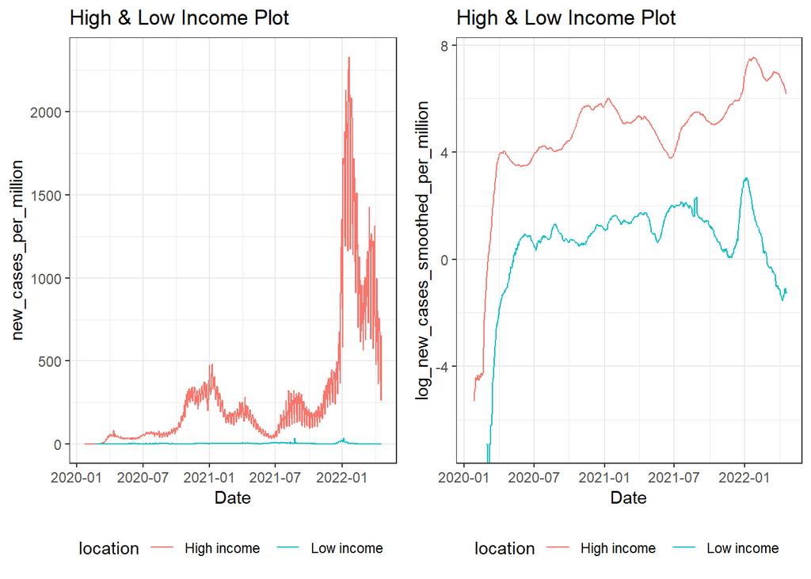

```r
covid_df$log_new_cases_smoothed_per_million = log(covid_df$new_cases_smoothed_per_million)

pl1 = plot_by_income(covid_df, "new_cases_per_million")
pl2 = plot_by_income(covid_df, "log_new_cases_smoothed_per_million") # smoothed
ggarrange(pl1, pl2 , ncol = 2, nrow = 1)
```

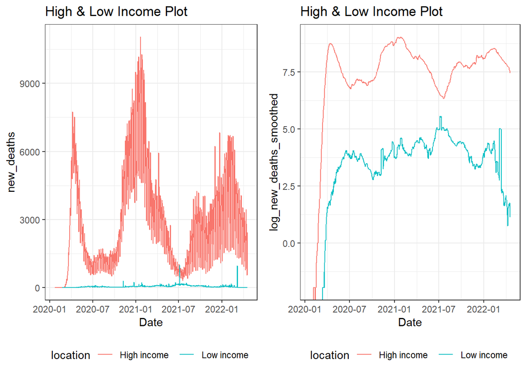

```r
covid_df$log_new_deaths_smoothed = log(covid_df$new_deaths_smoothed)

pl3 = plot_by_income(covid_df, "new_deaths")
pl4 = plot_by_income(covid_df, "log_new_deaths_smoothed") # smoothed
ggarrange(pl3, pl4 , ncol = 2, nrow = 1)
```

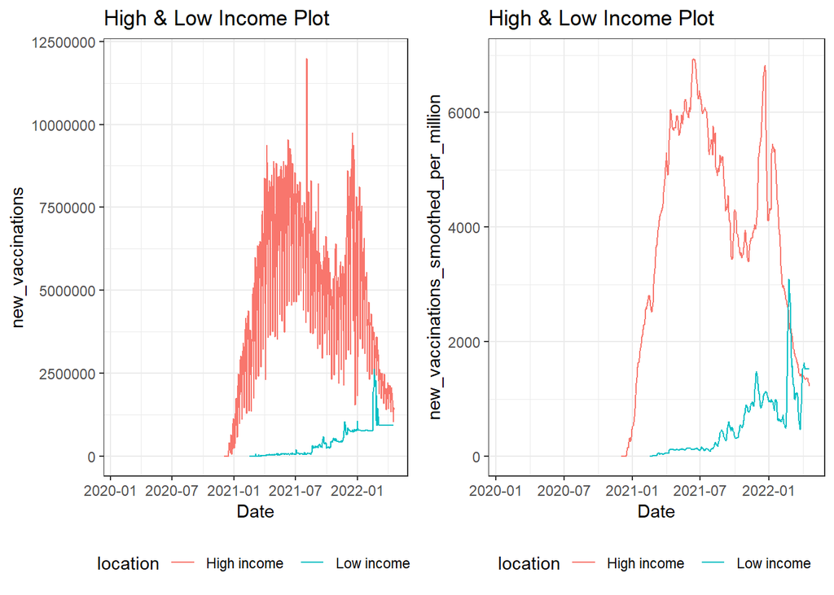

```r
covid_df$log_new_vaccinations_smoothed_per_million =
  log(covid_df$new_vaccinations_smoothed_per_million)

pl5 = plot_by_income(covid_df, "new_vaccinations")
pl6 = plot_by_income(covid_df, "new_vaccinations_smoothed_per_million") # smoothed
ggarrange(pl5, pl6 , ncol = 2, nrow = 1)
```

The plot which is easier to interpret is the log smoothed one because when we smooth the column values it’s easier to observe the changes in the low income countries (on the ‘regular’ plot we cannot interpret the low income graph at all as it seems monotone).

### 3. Storing and analyzing current (cumulative) value

#### a.

Generating df of current values by country

```r
vars = c('location', 'continent', 'total_cases_per_million','total_deaths_per_million',
'total_vaccinations_per_hundred', 'people_fully_vaccinated_per_hundred',
'total_boosters_per_hundred', 'excess_mortality_cumulative_per_million','date')

wanted_cur = subset(covid_df, select = vars) %>%  group_by(location)

filled_cur = fill(wanted_cur, names(wanted_cur), .direction = 'updown') # fill all na's

current = subset(filled_cur, date == max(wanted_cur$date))
current$date = NULL
```

We filled the values to be the last non Na value by date to be the most up dated value and with group_by we ran over the location and generated a data frame of the wanted variables by location.

#### b.

Empirical distribution

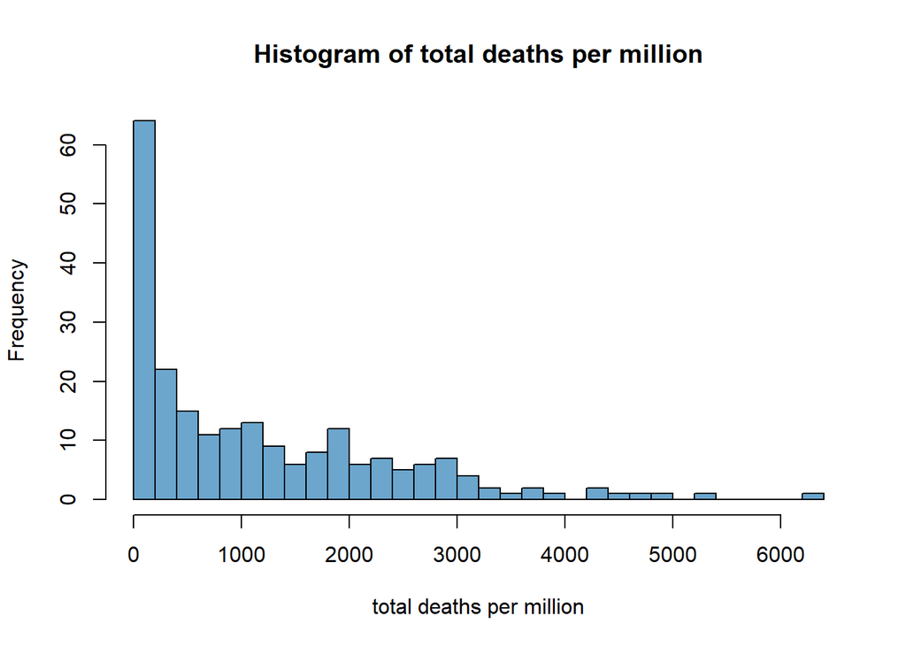

```r
hist(current$total_deaths_per_million, breaks= 30, col="skyblue3",
     main = "Histogram of total deaths per million", xlab= "total deaths per million")
```

```r
print(paste0("The distibution skewness: ", skewness(current$total_deaths_per_million, na.rm=T)))
```

```
## [1] "The distibution skewness: 1.30647361588152"
```

```r
print(paste0("The distibution kurtosis: ", kurtosis(current$total_deaths_per_million, na.rm=T)))
```

```
## [1] "The distibution kurtosis: 1.6238780513828"
```

#### c.

Scatter of total deaths & total cases with linear regression

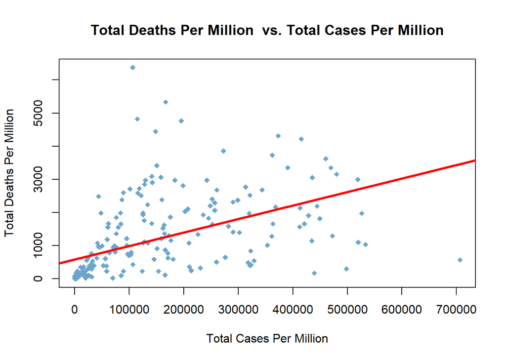

```r
total_cases_per_million = current$total_cases_per_million
total_deaths_per_million = current$total_deaths_per_million

plot(x=total_cases_per_million, y=total_deaths_per_million,
     main= 'Total Deaths Per Million  vs. Total Cases Per Million',
     xlab= 'Total Cases Per Million', ylab = 'Total Deaths Per Million',
     col= 'skyblue3', pch=18)

reg = lm(total_deaths_per_million ~ total_cases_per_million,)
abline(reg, col='red', lwd=3)
```

```r
print(paste0("The slope: ", summary(reg)$coefficients[2,1]))
```

```
## [1] "The slope: 0.0040800120531996"
```

Our slope is 0.004, which is positive and it means total cases per million and total deaths per million are positively (weak) correlated.

### 4. Vaccinations in different continents

#### a.

Boxplot of vaccinations per hundered for every continent

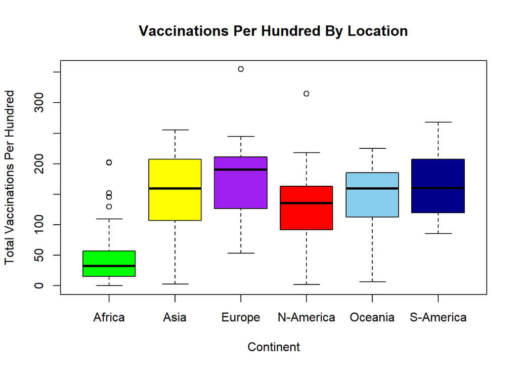

```r
continents = c('Africa','Asia', 'Europe','South America', 'North America', 'Oceania')
vaccinations_by_location = subset(current, select = c('continent', 'total_vaccinations_per_hundred'), continent %in% continents)

boxplot(total_vaccinations_per_hundred ~ continent, data = vaccinations_by_location,
        xlab = "Continent",
        ylab = "Total Vaccinations Per Hundred",
        main = "Vaccinations Per Hundred By Location",
        col = c("green","yellow","purple", "red","skyblue", "darkblue"),
        names= c('Africa', 'Asia', 'Europe', 'N-America', 'Oceania', 'S-America'))
```

```r
vaccinations_africa = subset(vaccinations_by_location, continent=='Africa')
vaccinations_europe = subset(vaccinations_by_location, continent=='Europe')

max_africa = max(vaccinations_africa$total_vaccinations_per_hundred, na.rm =T)
max_europe = max(vaccinations_europe$total_vaccinations_per_hundred, na.rm =T)

print(paste0("outlier 1: Seychelles, total vaccinations per hundred: ",max_africa))
```

```
## [1] "outlier 1: Seychelles, total vaccinations per hundred: 202.05"
```

```r
print(paste0("outlier 2: Gibraltar,  total vaccinations per hundred: ",max_europe))
```

```
## [1] "outlier 2: Gibraltar,  total vaccinations per hundred: 354.93"
```

Africa has the most outliers, it is not surprising since most of low income countries come from Africa. The mean of Africa is significantly different from other continents, without the outliers that drag it upwards it would have been even lower. All other means are more or less close becase their error bars are more or less close.

#### b.

Create & plot the booster ratio as a function of time for the six continents

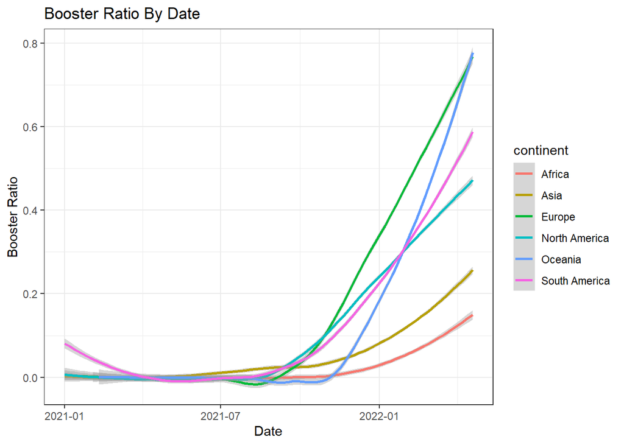

```r
booster_by_date =  covid_df %>% group_by(date, continent) %>% summarise(total_boosters = sum(total_boosters, na.rm = T) ,total_vaccinated = sum(people_fully_vaccinated, na.rm = T), booster_ratio =ifelse(total_vaccinated > 0,
total_boosters/total_vaccinated, NA)) %>% filter(continent %in% continents, date >= "2021-01-01")

ggplot(booster_by_date,
      aes_string(x="date", y='booster_ratio',color="continent")) +
      theme_bw() +
      geom_smooth() + # easier to interrupt using smooth
      labs(x="Date", y = 'Booster Ratio', title=("Booster Ratio By Date"))
```

### 5. Displaying monthly data

#### a.

plot the distribution of total number of `new_cases_per_million` for each country by month (in chronological order) then, doing the same for the total number of `new_deaths` and `new_vaccinations` for each month

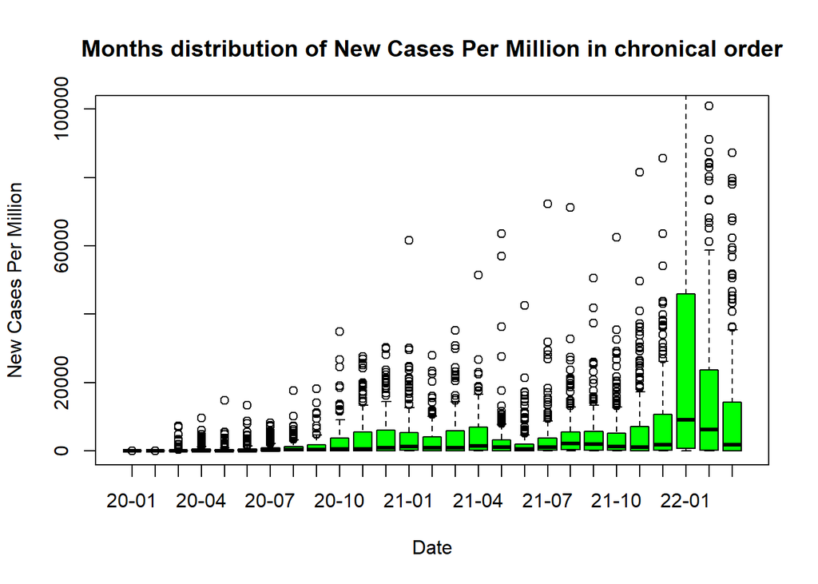

```r
month_df = subset(covid_df, date <= "2022-03-31" ) %>% group_by(date= format(as.Date(date),"%y-%m"), location) %>% summarise(
  new_cases_per_million = sum(new_cases_per_million), new_deaths = sum(new_deaths), new_vaccinations = sum(new_vaccinations))

boxplot(new_cases_per_million ~ date ,
data= month_df,
main="Months distribution of New Cases Per Million in chronical order",
ylim =c(0,100000), # y limit for better analysis of the plot
xlab = 'Date',
ylab = 'New Cases Per Million',
col = "green")
```

#### b.

Doing the same as (a.) for the total number of `new_deaths` and `new_vaccinations` for each month (chronological) we limit the y scale in order to be able to read th plots and analyse the graph.

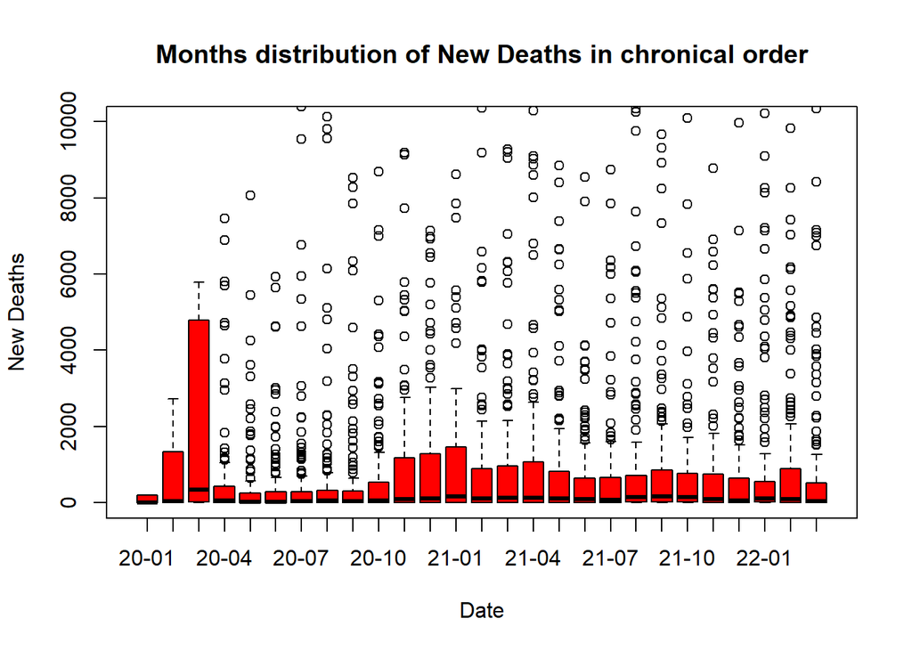

```r
boxplot(new_deaths ~ date ,
data= month_df,
main="Months distribution of New Deaths in chronical order",
ylim = c(0,10000), # y limit for better analysis of the plot
xlab = 'Date',
ylab = 'New Deaths',
col = "red")
```

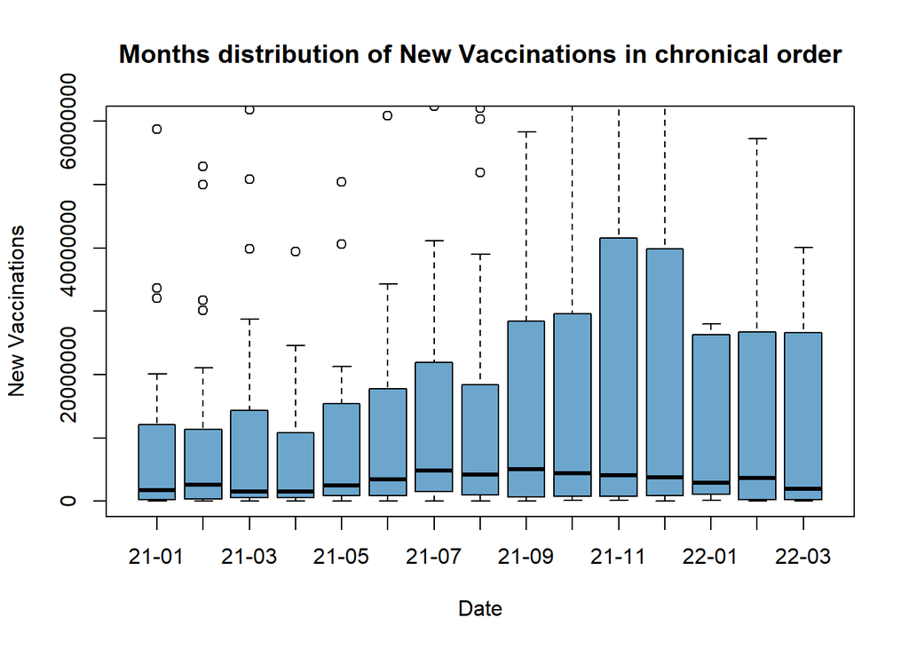

```r
boxplot(new_vaccinations ~ date ,
data= month_df,
main="Months distribution of New Vaccinations in chronical order",
ylim = c(0,60000000), # y limit for better analysis of the plot,
xlab = 'Date',
ylab = 'New Vaccinations',
col = "skyblue3")
```

Creating df with r cases for israel, UK & US.

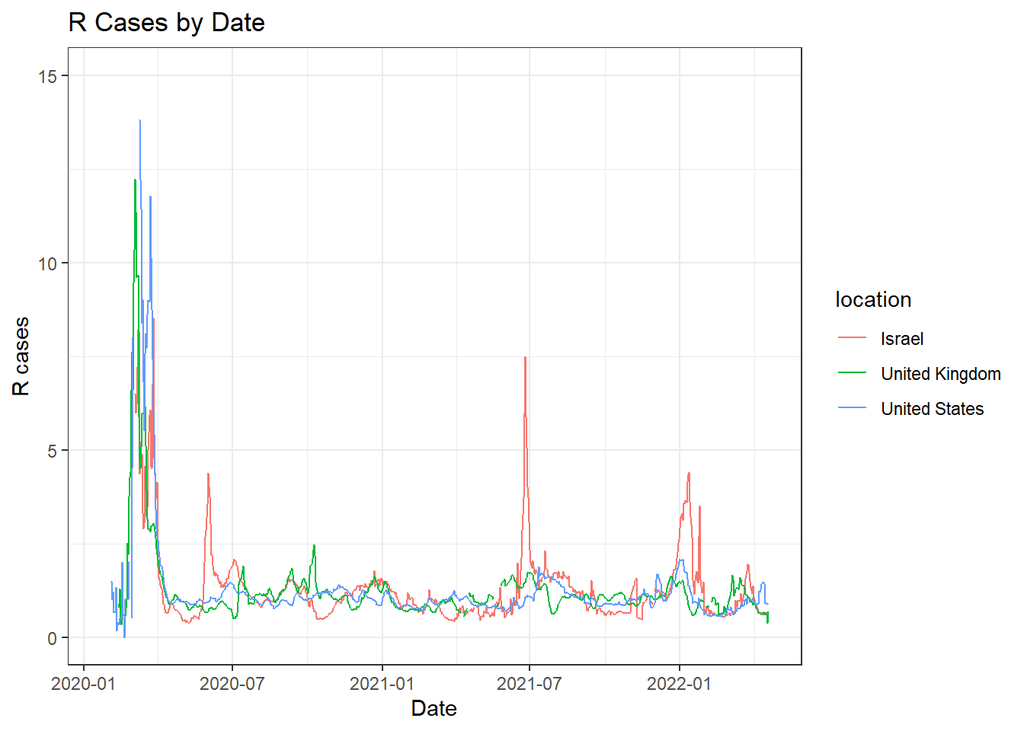

```r
covid_israel_uk_us = subset(covid_df, location %in% c('Israel', 'United Kingdom','United States'))%>% group_by(location) %>% mutate(R_cases = ifelse(lag(new_cases_smoothed, n = 7) > 0, new_cases_smoothed / lag(new_cases_smoothed, n = 7), NA))

ggplot(covid_israel_uk_us,
      aes_string(x="date", y='R_cases',color="location")) +
      geom_line()+
      theme_bw() +
      labs(x="Date", y = 'R cases', title=("R Cases by Date")) +
      scale_y_continuous(limits = c(0,15)) # y limit for better analysis of the plot
```

in order to get a better picture of the graph and see all the trends in the countries we limit the y lab to avoid the dramatic usa increase. We can tell that all R values above 1 indicates the increase of covid. R values above 1 are also in similar dates as its around a wave of infection, That shows how spreading of new variants create infection waves.

### 6. Displaying data on the world map

Displaying the data using `joinCountryData2Map` function for the variables `total_deaths_per_million`, `total_vaccinations_per_hundred`, `excess_mortality_cumulative_per_million`

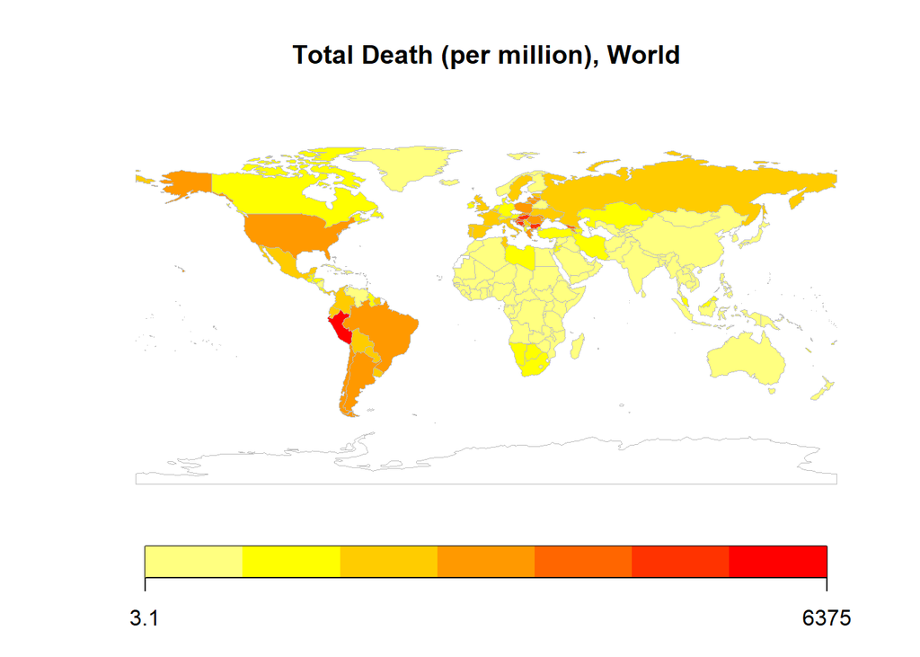

```r
map = joinCountryData2Map(current, joinCode = "NAME", nameJoinColumn = "location")

mapCountryData(map, nameColumnToPlot = "total_deaths_per_million", catMethod = "FixedWidth", mapTitle= "Total Death (per million), World" )
```

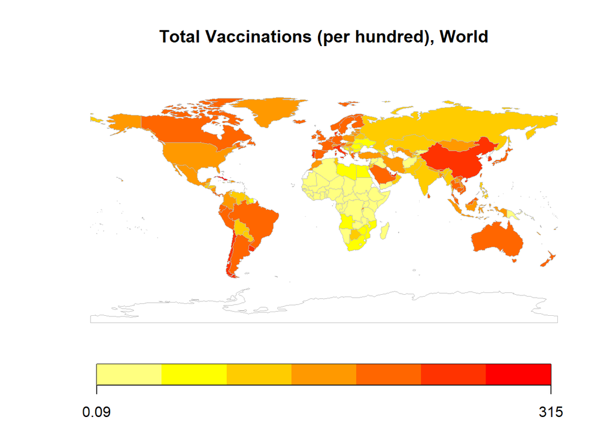

```r
mapCountryData(map, nameColumnToPlot = "total_vaccinations_per_hundred", catMethod = "FixedWidth", mapTitle = "Total Vaccinations (per hundred), World")
```

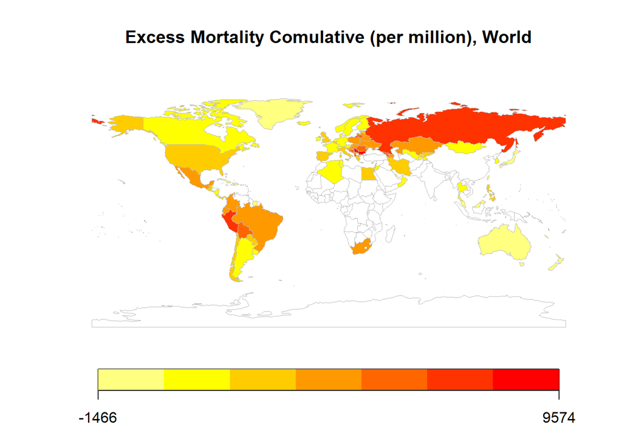

```r
mapCountryData(map, nameColumnToPlot = "excess_mortality_cumulative_per_million", catMethod = "FixedWidth", mapTitle = "Excess Mortality Comulative (per million), World")
```

Tables for the top 3 countries for those variables

```r
head(subset(current,select=c(location, total_deaths_per_million))
     [order(current$total_deaths_per_million, decreasing = TRUE),],3)
```

[output not shown]

```r
head(subset(current,select=c(location, total_vaccinations_per_hundred))
     [order(current$total_vaccinations_per_hundred, decreasing = TRUE),],3)
```

[output not shown]

```r
head(subset(current,select=c(location, excess_mortality_cumulative_per_million))
     [order(current$excess_mortality_cumulative_per_million, decreasing = TRUE),],3)
```

[output not shown]

### 7. Cross correlations and delay from diagnosis to death

#### a.

Function that generates cross cor vector for 2 column vector from a given data frame.

```r
cross_cor = function(df, country_name, col_1, col_2){

  new_df = subset(covid_df, location == country_name, select = c(col_1, col_2))

  cross_cor_vec = c()
  vec1 = new_df[,col_1]
  vec2 = new_df[,col_2]
  n = length(vec1)

  counter = 1

    for(t in -60:60){

    if(t <= 0){
      cross_cor_vec[counter] = cor(vec1[(1-t):n], vec2[1:(n+t)], use="pairwise.complete.obs") }

    else{
      cross_cor_vec[counter] = cor(vec1[1:(n-t)], vec2[(t+1):n],use="pairwise.complete.obs") }

      counter = counter + 1
    }

  replace_na(cross_cor_vec, 0) # in case of an unwanted NA
  return(cross_cor_vec)
}
```

#### b.

Cross correlation between the `new_cases_smoothed` & `new_deaths_smoothed` for `World`, plot as a function of `delta_t` above

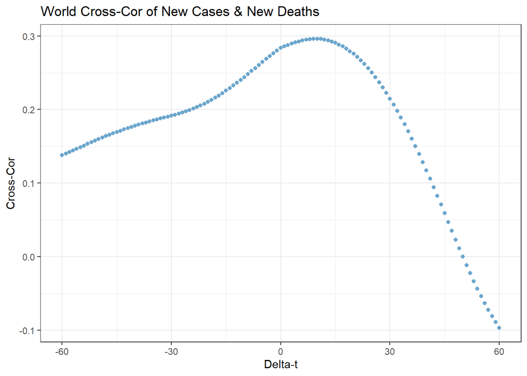

```r
cross_World = cross_cor(covid_df,'World','new_cases_smoothed','new_deaths_smoothed')

ggplot(df = data.frame(cross_World, -60:60)) +
  aes(x =-60:60, y = cross_World)+
  theme_bw() +
  geom_point(color = 'skyblue3')+
  labs(x='Delta-t', y = 'Cross-Cor', title=("World Cross-Cor of New Cases & New Deaths"))
```

```r
print(paste0("Time delay that maximize cross-cor: ", (which.max(cross_World) - 61))) # length(-60:60)/2 = 121/2, rounding upwards to 61
```

```
## [1] "Time delay that maximize cross-cor: 10"
```

As we can see the Time delay that maximize cross-cor is 10 which means the typical time delay between diagnosis of Covid-19 and death from Covid-19 for cases not surviving the disease is 10.

### 9. Death risk after Covid-19 infection

#### a.

Creating and plotting death rate as a function of time for all continents, world

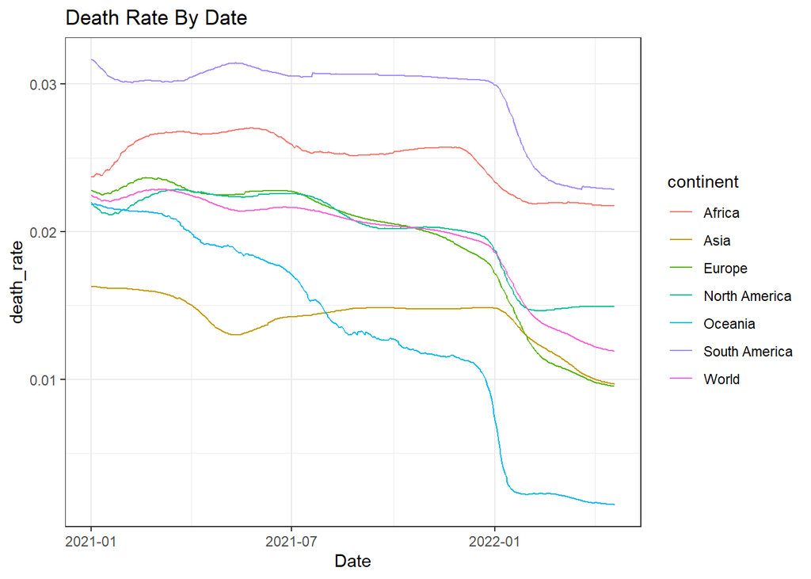

```r
covid_df$death_rate = ifelse(covid_df$total_cases > 0, covid_df$total_deaths/covid_df$total_cases, NA)

covid_by_continent_date =  na.omit(group_by(covid_df, date, continent) %>% summarise(sum_total_cases = sum(total_cases, na.rm = T), sum_total_deaths = sum(total_deaths, na.rm = T), death_rate =ifelse(sum_total_cases > 0, sum_total_deaths/sum_total_cases, NA)) %>% filter(date >= as.Date('2021-01-01')))
covid_by_continent_date$continent[covid_by_continent_date$continent==''] = 'World'

ggplot(covid_by_continent_date,
      aes_string(x="date", y='death_rate',color="continent")) +
      geom_line() +
      theme_bw() +
      labs(x="Date", y = 'death_rate', title=("Death Rate By Date"))
```

#### b.

A similar plot for all continents and the world, but for `total_vaccinations_per_hundred`.

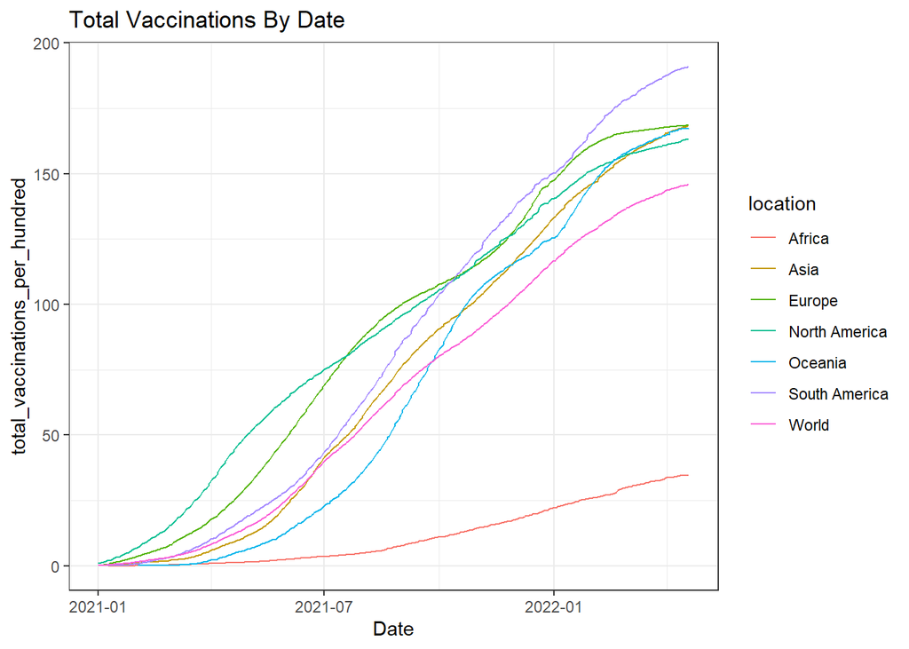

```r
covid_by_date_location = na.omit(subset(covid_df, select = c(date, location, total_vaccinations_per_hundred), date >= as.Date('2021-01-01'))) %>% filter(location %in% c(continents, 'World'))

ggplot(covid_by_date_location,
      aes_string(x="date", y='total_vaccinations_per_hundred',color="location")) +
      geom_line() +
      theme_bw() +
      labs(x="Date", y = 'total_vaccinations_per_hundred', title=("Total Vaccinations By Date"))
```

We can see correlation between decrease in death rate and vaccinations appearance. the death rate dropped drastically and remain low as the vaccinations took place.

### 9. Excess Mortality

#### a.

Visualizing the excess mortality outlier countries and marking them on the graph

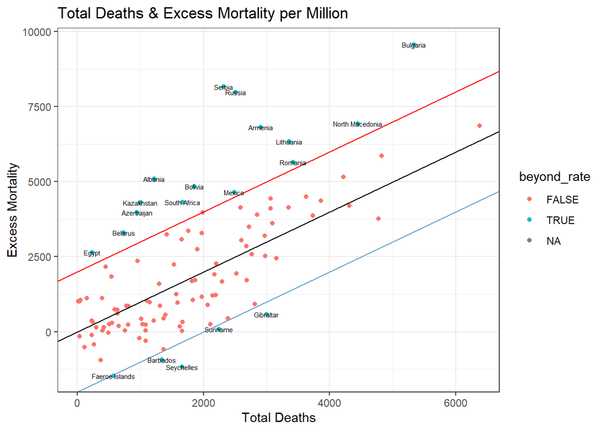

```r
low_line = geom_abline(intercept = -2000, slope = 1, col = 'skyblue3')
up_line = geom_abline(intercept = 2000, slope = 1, col = 'red')
middle_line = geom_abline(intercept = 0, slope = 1)
beyond_rate = abs(current$excess_mortality_cumulative_per_million-total_deaths_per_million)>=2000
ggplot(current)+
  aes(x=total_deaths_per_million, y=excess_mortality_cumulative_per_million) +
  theme_bw() +
  geom_point(aes(color = beyond_rate)) +
  middle_line +
  up_line +
  low_line +
  geom_text(aes(label=ifelse(beyond_rate, location, "")), size = 2) +
  labs(x="Total Deaths", y = 'Excess Mortality', title=("Total Deaths & Excess Mortality per Million"))
```

#### b.

Plotting three outlier countries(above 2000) in terms of `excess_mortality`.

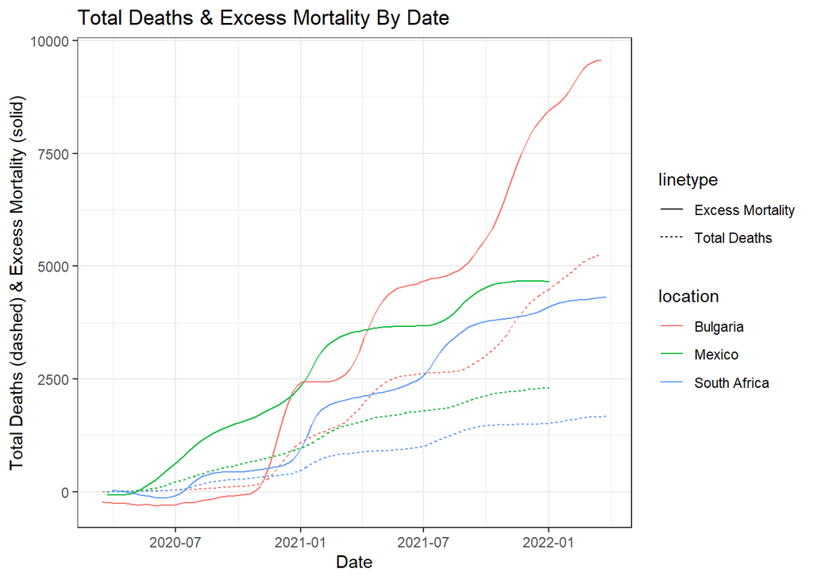

```r
cov_mortality = subset(covid_df, location %in% c('Bulgaria', 'Mexico', 'South Africa'), select = c("location", "total_deaths_per_million","excess_mortality_cumulative_per_million", "date"))

ggplot(na.omit(cov_mortality), aes_string(x='date', color = 'location')) +
  geom_line(aes(y=total_deaths_per_million, linetype = 'Total Deaths')) +
  geom_line(aes(y=excess_mortality_cumulative_per_million, linetype = "Excess Mortality")) +
  theme_bw() +
  scale_x_date(name = 'Date') +
  scale_y_continuous(name = "Total Deaths (dashed) & Excess Mortality (solid)") +
  ggtitle("Total Deaths & Excess Mortality By Date")
```